Emre Derman HW_4 21703508

Describe the null hypotheses to which the p-values given in Table 3.4 correspond. Explain what conclusions you can draw based on these p-values. Your explanation should be phrased in terms of sales, TV, radio, and newspaper, rather than in terms of the coefficients of the linear model.

```r
 # The p-values given in the table report the partial effect of adding that variable to the model.The p-value for TV corresponds to a null hypothesis that the coefficient for TV is zero,since the p-value for TV is essentially zero, there is strong evidence that TV advertising is related to sales.Things are similar for radio and newspaper. The p-value for newspaper corresponds to a null hypothesis that the coefficient   for newspaper is zero
```

Suppose we have a data set with five predictors, X1 = GPA, X2 = IQ, X3 = Level (1 for College and 0 for High School), X4 = Interaction between GPA and IQ, and X5 = Interaction between GPA and Level. The response is starting salary after graduation (in thousands of dollars). Suppose we use least squares to fit the model, and get ˆ β0 = 50, ˆ β1 = 20, ˆ β2 = 0.07, ˆ β3 = 35, ˆ β4 = 0.01, ˆ β5 = −10.

1. Which answer is correct, and why?
1. For a fixed value of IQ and GPA, high school graduates earn more, on average, than college graduates.
2. For a fixed value of IQ and GPA, college graduates earn more, on average, than high school graduates.
3. For a fixed value of IQ and GPA, high school graduates earn more, on average, than college graduates provided that the GPA is high enough.
4. For a fixed value of IQ and GPA, college graduates earn more, on average, than high school graduates provided that the GPA is high enough.

```r
# The third answer is correct. Suppose we have fixed values for GPA and IQ:
# X1 = a (GPA)  and  X2 = b(IQ) .
# Plugging into the least squares regression model and rearranging, the result would be
```

$$\hat{y} = 50+20a+0.07b+0.01ab+(35−10a)X3.$$

For lower GPA values ( a<3.5 ), the coefficient of X3 is positive, meaning that for a fixed value of IQ and a fixed GPA value less than 3.5, College earn more on average than High School, as X3=1 for college and is zero for High School For GPA values above 3.5, the coefficient of X3 becomes negative, meaning that for a fixed value of IQ and a fixed GPA value greater than 3.5, High School earn more on average. Hence, the model says that for a fixed value of IQ and GPA, High school earn more on average than college, provided that the GPA is high enough.

[output not shown]

$$\hat{y} = 50+20(4.0)+0.07(110)+35(1)+0.01(4.0)(110)−10(4.0)(1)
= 137.1.$$

3. True or false: Since the coefficient for the GPA/IQ interaction term is very small, there is very little evidence of an interaction effect. Justify your answer.

```r
# False.
# The value of the coefficient for an interaction term doesn't provide evidence for  the possibility of an interaction effect.
#In order to actually make a statement about evidence of an interaction effect, or lack thereof, we would need to either be given or compute a p-value for the coefficient of the interaction term.
```

I collect a set of data (n = 100 observations) containing a single predictor and a quantitative response. I then fit a linear regression model to the data, as well as a separate cubic regression, i.e. Y = β0 + β1X + β2X2 + β3X3 + ϵ.

1. Suppose that the true relationship between X and Y is linear, i.e. Y = β0 + β1X + ϵ. Consider the training residual sum of squares (RSS) for the linear regression, and also the training RSS for the cubic regression. Would we expect one to be lower than the other, would we expect them to be the same, or is there not enough information to tell? Justify your answer.

```r
# The expected training RSS for the cubic regression to be lower than that of the linear regression, # since cubic regression has a higher level of flexibility. As the flexibility of a model increases, # the training mean squared error, which is equal to the product of the training RSS and the number # of observations  n , decreases orderly. This is regardless of the nature of the true relationship between  X  and  Y .
```

2. Answer (a) using test rather than training RSS.

```r
# The linear regression's predicted test RSS is smaller than the cubic regression's. Test RSS is affected by the model's variance and squared bias, as well as the variance of. As In this case, the connection is linear, therefore linear regression has less bias than cubic regression. Furthermore, because variance is a measure of how much the model would vary if we estimated it using a different training set, linear regression, as a less-flexible model, always has less variance than cubic regression. Thus, since the variance of  ϵ  is a constant and the linear model has lower bias and variance compared to the cubic model, linear regression will result in a lower test RSS compared to cubic regression.
```

3. Suppose that the true relationship between X and Y is not linear, but we don’t know how far it is from linear. Consider the training RSS for the linear regression, and also the training RSS for the cubic regression. Would we expect one to be lower than the other, would we expect them to be the same, or is there not enough information to tell? Justify your answer.

```r
# Similar to part (1), I would expect the training RSS for the cubic regression to be lower than that of the linear regression. Again this is due to the fact that cubic regression has a higher level of flexibility, and increased flexibility results in lower training mean squared error, and hence lower training RSS.
```

4. Answer (c) using test rather than training RSS.

```r
#In this situation, Because the underlying link is not linear, cubic regression will likely have less bias than linear regression. We don't know the amount of the difference in bias between the two models since we don't know how far it's from linear. Moreover, as noted in part (2), cubic regression has higher variance than linear regression, so the accuracy of a cubic regression model depends more on the training data. Since we don't know anything about the training data, we don't know how well it actually represents the relationshp between the predictor and the response. Because we don't know the size of the difference in bias between the two models, and also since cubic regression has higher variance and we don't know anything further about the training data, we don't have enough information to compare the values of the test RSS between the two models in this situation.
```

This question involves the use of simple linear regression on the Auto data set. (a) Use the lm() function to perform a simple linear regression with mpg as the response and horsepower as the predictor. Use the summary() function to print the results. Comment on the output.

```r
library(ISLR)
library(MASS)
data("Auto")
head(Auto)
```

```
##   mpg cylinders displacement horsepower weight acceleration year origin
## 1  18         8          307        130   3504         12.0   70      1
## 2  15         8          350        165   3693         11.5   70      1
## 3  18         8          318        150   3436         11.0   70      1
## 4  16         8          304        150   3433         12.0   70      1
## 5  17         8          302        140   3449         10.5   70      1
## 6  15         8          429        198   4341         10.0   70      1
##                        name
## 1 chevrolet chevelle malibu
## 2         buick skylark 320
## 3        plymouth satellite
## 4             amc rebel sst
## 5               ford torino
## 6          ford galaxie 500
```

```r
lm.fit<- lm(mpg~horsepower,data=Auto)
summary(lm.fit)
```

```
##
## Call:
## lm(formula = mpg ~ horsepower, data = Auto)
##
## Residuals:
##      Min       1Q   Median       3Q      Max
## -13.5710  -3.2592  -0.3435   2.7630  16.9240
##
## Coefficients:
##              Estimate Std. Error t value Pr(>|t|)
## (Intercept) 39.935861   0.717499   55.66   <2e-16 ***
## horsepower  -0.157845   0.006446  -24.49   <2e-16 ***
## ---
## Signif. codes:  0 '***' 0.001 '**' 0.01 '*' 0.05 '.' 0.1 ' ' 1
##
## Residual standard error: 4.906 on 390 degrees of freedom
## Multiple R-squared:  0.6059, Adjusted R-squared:  0.6049
## F-statistic: 599.7 on 1 and 390 DF,  p-value: < 2.2e-16
```

For example: i. Is there a relationship between the predictor and the response?

```r
#Yes, since p value is 2.2e-16
```

2. How strong is the relationship between the predictor and the response

```r
# The R^2 value indicates that about 61% of the variation in the response variable ( mpg) is due to the predictor variable (horsepower).
```

3. Is the relationship between the predictor and the response positive or negative?

```r
 # Negative
```

4. What is the predicted mpg associated with a horsepower of 98? What are the associated 95% confidence and prediction intervals?

```r
predict(lm.fit,data.frame(horsepower=c(98)),interval="prediction")
```

```
##        fit     lwr      upr
## 1 24.46708 14.8094 34.12476
```

```r
predict(lm.fit,data.frame(horsepower=c(98)),interval="confidence")
```

```
##        fit      lwr      upr
## 1 24.46708 23.97308 24.96108
```

2. Plot the response and the predictor. Use the abline() function to display the least squares regression line.

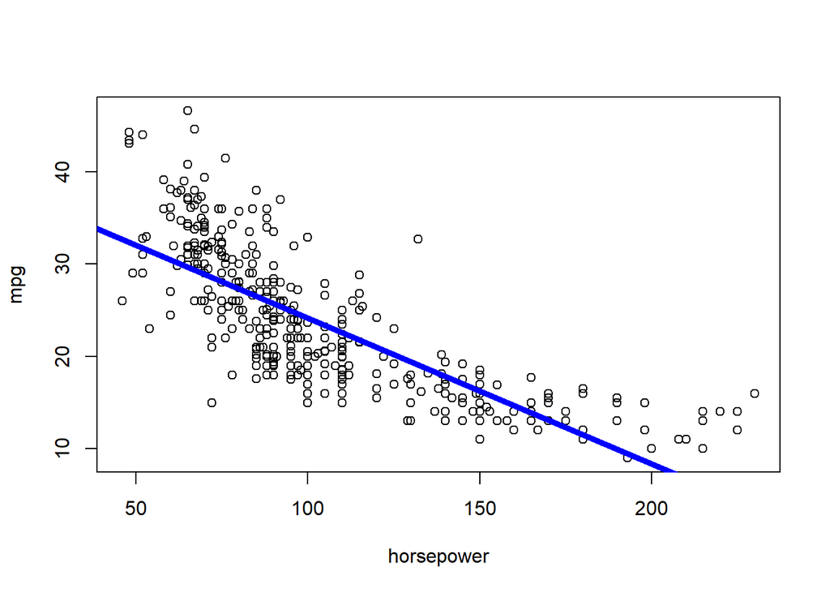

```r
attach(Auto)
plot(horsepower,mpg)
abline(lm.fit,lwd=5,col="blue")
```

```r
which.max(hatvalues(lm.fit))
```

```
## 117
## 116
```